# Sampling distributions and standard errors - mini lab

NB Homework substitution instead of usual day 3

Lesley Duff

2023-08-30

# Sampling distributions and standard errors - mini lab

1. Load and explore the data held in `heart.csv`. A data dictionary is also available.

```r
library(tidyverse)
heart <- read_csv("data/heart.csv")
head(heart)
```

| age | sex | cp | trestbps | chol | fbs | restecg | thalach | exang | oldpeak | slope | ca | thal | target |
| --- | --- | --- | --- | --- | --- | --- | --- | --- | --- | --- | --- | --- | --- |
| 63 | 1 | 3 | 145 | 233 | 1 | 0 | 150 | 0 | 2.3 | 0 | 0 | 1 | 1 |
| 37 | 1 | 2 | 130 | 250 | 0 | 1 | 187 | 0 | 3.5 | 0 | 0 | 2 | 1 |
| 41 | 0 | 1 | 130 | 204 | 0 | 0 | 172 | 0 | 1.4 | 2 | 0 | 2 | 1 |
| 56 | 1 | 1 | 120 | 236 | 0 | 1 | 178 | 0 | 0.8 | 2 | 0 | 2 | 1 |
| 57 | 0 | 0 | 120 | 354 | 0 | 1 | 163 | 1 | 0.6 | 2 | 0 | 2 | 1 |
| 57 | 1 | 0 | 140 | 192 | 0 | 1 | 148 | 0 | 0.4 | 1 | 0 | 1 | 1 |

```r
glimpse(heart)
```

```
## Rows: 303
## Columns: 14
## $ age      <dbl> 63, 37, 41, 56, 57, 57, 56, 44, 52, 57, 54, 48, 49, 64, 58, 5…
## $ sex      <dbl> 1, 1, 0, 1, 0, 1, 0, 1, 1, 1, 1, 0, 1, 1, 0, 0, 0, 0, 1, 0, 1…
## $ cp       <dbl> 3, 2, 1, 1, 0, 0, 1, 1, 2, 2, 0, 2, 1, 3, 3, 2, 2, 3, 0, 3, 0…
## $ trestbps <dbl> 145, 130, 130, 120, 120, 140, 140, 120, 172, 150, 140, 130, 1…
## $ chol     <dbl> 233, 250, 204, 236, 354, 192, 294, 263, 199, 168, 239, 275, 2…
## $ fbs      <dbl> 1, 0, 0, 0, 0, 0, 0, 0, 1, 0, 0, 0, 0, 0, 1, 0, 0, 0, 0, 0, 0…
## $ restecg  <dbl> 0, 1, 0, 1, 1, 1, 0, 1, 1, 1, 1, 1, 1, 0, 0, 1, 1, 1, 1, 1, 1…
## $ thalach  <dbl> 150, 187, 172, 178, 163, 148, 153, 173, 162, 174, 160, 139, 1…
## $ exang    <dbl> 0, 0, 0, 0, 1, 0, 0, 0, 0, 0, 0, 0, 0, 1, 0, 0, 0, 0, 0, 0, 0…
## $ oldpeak  <dbl> 2.3, 3.5, 1.4, 0.8, 0.6, 0.4, 1.3, 0.0, 0.5, 1.6, 1.2, 0.2, 0…
## $ slope    <dbl> 0, 0, 2, 2, 2, 1, 1, 2, 2, 2, 2, 2, 2, 1, 2, 1, 2, 0, 2, 2, 1…
## $ ca       <dbl> 0, 0, 0, 0, 0, 0, 0, 0, 0, 0, 0, 0, 0, 0, 0, 0, 0, 0, 0, 2, 0…
## $ thal     <dbl> 1, 2, 2, 2, 2, 1, 2, 3, 3, 2, 2, 2, 2, 2, 2, 2, 2, 2, 2, 2, 3…
## $ target   <dbl> 1, 1, 1, 1, 1, 1, 1, 1, 1, 1, 1, 1, 1, 1, 1, 1, 1, 1, 1, 1, 1…
```

```r
str(heart)
```

```
## spc_tbl_ [303 × 14] (S3: spec_tbl_df/tbl_df/tbl/data.frame)
##  $ age     : num [1:303] 63 37 41 56 57 57 56 44 52 57 ...
##  $ sex     : num [1:303] 1 1 0 1 0 1 0 1 1 1 ...
##  $ cp      : num [1:303] 3 2 1 1 0 0 1 1 2 2 ...
##  $ trestbps: num [1:303] 145 130 130 120 120 140 140 120 172 150 ...
##  $ chol    : num [1:303] 233 250 204 236 354 192 294 263 199 168 ...
##  $ fbs     : num [1:303] 1 0 0 0 0 0 0 0 1 0 ...
##  $ restecg : num [1:303] 0 1 0 1 1 1 0 1 1 1 ...
##  $ thalach : num [1:303] 150 187 172 178 163 148 153 173 162 174 ...
##  $ exang   : num [1:303] 0 0 0 0 1 0 0 0 0 0 ...
##  $ oldpeak : num [1:303] 2.3 3.5 1.4 0.8 0.6 0.4 1.3 0 0.5 1.6 ...
##  $ slope   : num [1:303] 0 0 2 2 2 1 1 2 2 2 ...
##  $ ca      : num [1:303] 0 0 0 0 0 0 0 0 0 0 ...
##  $ thal    : num [1:303] 1 2 2 2 2 1 2 3 3 2 ...
##  $ target  : num [1:303] 1 1 1 1 1 1 1 1 1 1 ...
##  - attr(*, "spec")=
##   .. cols(
##   ..   age = col_double(),
##   ..   sex = col_double(),
##   ..   cp = col_double(),
##   ..   trestbps = col_double(),
##   ..   chol = col_double(),
##   ..   fbs = col_double(),
##   ..   restecg = col_double(),
##   ..   thalach = col_double(),
##   ..   exang = col_double(),
##   ..   oldpeak = col_double(),
##   ..   slope = col_double(),
##   ..   ca = col_double(),
##   ..   thal = col_double(),
##   ..   target = col_double()
##   .. )
##  - attr(*, "problems")=<externalptr>
```

2. Plot a histogram and/or boxplot for `thalach` (maximum heart rate achieved in stress testing).

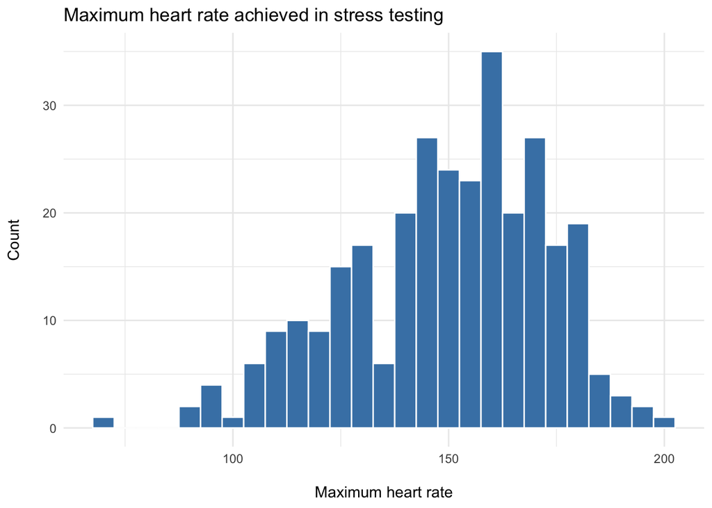

```r
heart %>%
  ggplot(aes(x = thalach)) +
    geom_histogram(colour = "white",
                   fill = "steelblue",
                   binwidth = 5) +
    labs(
      title = "Maximum heart rate achieved in stress testing",
      x = "\nMaximum heart rate",
      y = "Count\n"
    ) +
  theme_minimal()
```

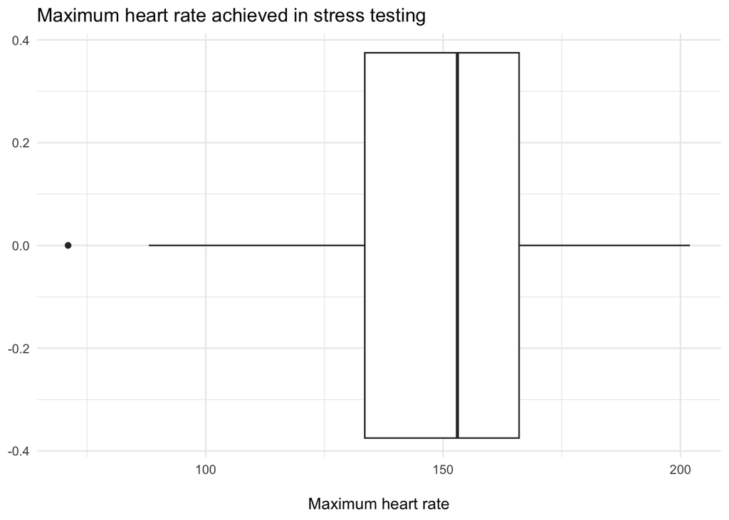

```r
heart %>%
  ggplot(aes(x = thalach)) +
    geom_boxplot() +
    labs(
      title = "Maximum heart rate achieved in stress testing",
      x = "\nMaximum heart rate"#
    ) +
  theme_minimal()
```

How normal is the distribution?

```r
library(e1071)

heart %>%
  summarise(skewness = skewness(thalach, type = 1))
```

| skewness |
| --- |
| -0.5347455 |

This is a moderately left-skewed distribution.

3. Also plot a barplot of `exang` (whether the patient displayed exercise induced angina)

```r
str(heart)
```

```
## spc_tbl_ [303 × 14] (S3: spec_tbl_df/tbl_df/tbl/data.frame)
##  $ age     : num [1:303] 63 37 41 56 57 57 56 44 52 57 ...
##  $ sex     : num [1:303] 1 1 0 1 0 1 0 1 1 1 ...
##  $ cp      : num [1:303] 3 2 1 1 0 0 1 1 2 2 ...
##  $ trestbps: num [1:303] 145 130 130 120 120 140 140 120 172 150 ...
##  $ chol    : num [1:303] 233 250 204 236 354 192 294 263 199 168 ...
##  $ fbs     : num [1:303] 1 0 0 0 0 0 0 0 1 0 ...
##  $ restecg : num [1:303] 0 1 0 1 1 1 0 1 1 1 ...
##  $ thalach : num [1:303] 150 187 172 178 163 148 153 173 162 174 ...
##  $ exang   : num [1:303] 0 0 0 0 1 0 0 0 0 0 ...
##  $ oldpeak : num [1:303] 2.3 3.5 1.4 0.8 0.6 0.4 1.3 0 0.5 1.6 ...
##  $ slope   : num [1:303] 0 0 2 2 2 1 1 2 2 2 ...
##  $ ca      : num [1:303] 0 0 0 0 0 0 0 0 0 0 ...
##  $ thal    : num [1:303] 1 2 2 2 2 1 2 3 3 2 ...
##  $ target  : num [1:303] 1 1 1 1 1 1 1 1 1 1 ...
##  - attr(*, "spec")=
##   .. cols(
##   ..   age = col_double(),
##   ..   sex = col_double(),
##   ..   cp = col_double(),
##   ..   trestbps = col_double(),
##   ..   chol = col_double(),
##   ..   fbs = col_double(),
##   ..   restecg = col_double(),
##   ..   thalach = col_double(),
##   ..   exang = col_double(),
##   ..   oldpeak = col_double(),
##   ..   slope = col_double(),
##   ..   ca = col_double(),
##   ..   thal = col_double(),
##   ..   target = col_double()
##   .. )
##  - attr(*, "problems")=<externalptr>
```

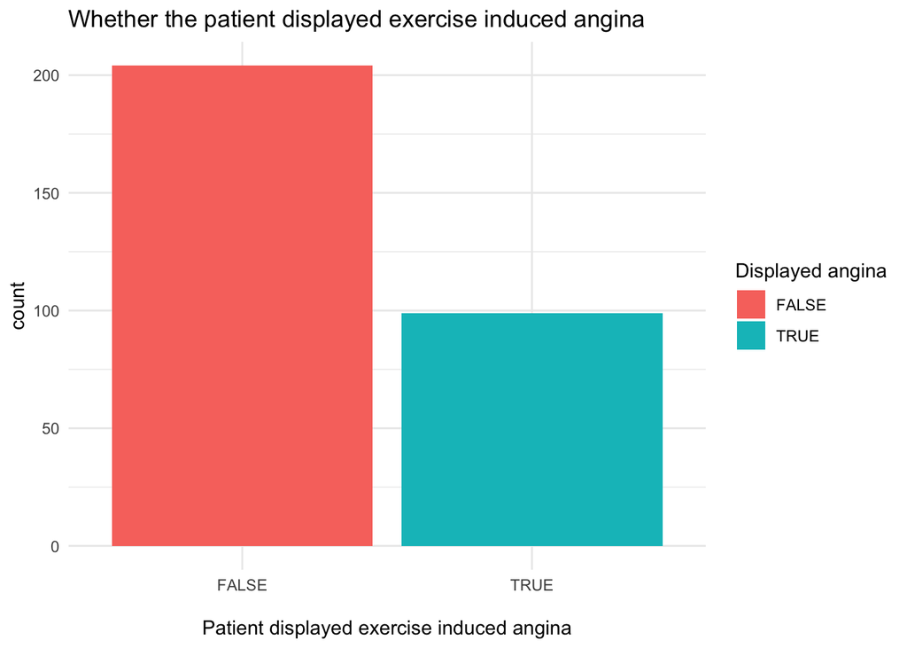

```r
  heart %>%
    mutate(exang = as.logical(exang)) %>%
  ggplot(aes(x = exang, fill = exang)) +
    geom_bar(aes(fill = exang)) +
    labs(
      title = "Whether the patient displayed exercise induced angina",
      x = "\nPatient displayed exercise induced angina",
      fill = "Displayed angina"
    ) +
  theme_minimal()
```

4. Now calculate population parameters: what is the mean `thalach` in the population. What proportion of patients have exercise induced angina (`exang`)?

```r
summary_popn <- heart %>%
  summarise(
    mean_thalach = mean(thalach),
    prop_exang = sum(exang == 1) / n()
  )

summary_popn
```

| mean_thalach | prop_exang |
| --- | --- |
| 149.6469 | 0.3267327 |

- Mean `thalach` in the population: 149.6468647.
- Proportion of patients with exercise induced angina (`exang`): 0.3267327.
5. Now take a single sample of 50-patients from the population and calculate point estimates for mean `thalach` and proportion of `exang` from this sample (let’s call these `mean_thalach` and `prop_exang` going forward).  
   [**Hint** - use `rep_sample_n()` from the `infer` package to do this]

```r
library(infer)

sample_50 <- heart %>%
  # ?rep_sample_n
  rep_sample_n(size = 50, reps = 1) %>%
#  get rid of error '-' only defined for equally-sized data frames
  ungroup()

sample_50
```

| replicate | age | sex | cp | trestbps | chol | fbs | restecg | thalach | exang | oldpeak | slope | ca | thal | target |
| --- | --- | --- | --- | --- | --- | --- | --- | --- | --- | --- | --- | --- | --- | --- |
| 1 | 40 | 1 | 0 | 152 | 223 | 0 | 1 | 181 | 0 | 0.0 | 2 | 0 | 3 | 0 |
| 1 | 53 | 1 | 2 | 130 | 197 | 1 | 0 | 152 | 0 | 1.2 | 0 | 0 | 2 | 1 |
| 1 | 41 | 0 | 1 | 126 | 306 | 0 | 1 | 163 | 0 | 0.0 | 2 | 0 | 2 | 1 |
| 1 | 68 | 0 | 2 | 120 | 211 | 0 | 0 | 115 | 0 | 1.5 | 1 | 0 | 2 | 1 |
| 1 | 35 | 0 | 0 | 138 | 183 | 0 | 1 | 182 | 0 | 1.4 | 2 | 0 | 2 | 1 |
| 1 | 63 | 0 | 0 | 150 | 407 | 0 | 0 | 154 | 0 | 4.0 | 1 | 3 | 3 | 0 |
| 1 | 59 | 1 | 2 | 126 | 218 | 1 | 1 | 134 | 0 | 2.2 | 1 | 1 | 1 | 0 |
| 1 | 44 | 1 | 1 | 120 | 263 | 0 | 1 | 173 | 0 | 0.0 | 2 | 0 | 3 | 1 |
| 1 | 54 | 0 | 1 | 132 | 288 | 1 | 0 | 159 | 1 | 0.0 | 2 | 1 | 2 | 1 |
| 1 | 47 | 1 | 2 | 130 | 253 | 0 | 1 | 179 | 0 | 0.0 | 2 | 0 | 2 | 1 |

[output cut: 40 more lines]

```r
summary_sample_50 <- sample_50 %>%
  summarise(
    mean_thalach = mean(thalach),
    prop_exang = sum(exang == 1) / n()
   )

summary_sample_50
```

| mean_thalach | prop_exang |
| --- | --- |
| 153.84 | 0.22 |

6. What are the sampling errors of these point estimates?  
   [**Hint** - remember a *sampling error* is defined as the difference between a *point estimate* drawn from a sample, and a *population parameter*]

```r
# Sampling error = point estimate - population parameter
sampling_error = summary_sample_50 - summary_popn
sampling_error
```

| mean_thalach | prop_exang |
| --- | --- |
| 4.193135 | -0.1067327 |

7. Now we’re going to repeatedly sample 50-patients from the population and build up sampling distributions for the `mean_thalach` and `prop_exang` point estimates. Take 5000 samples and store the sampling distributions in a variable `rep_sample_50`.  
   [**Hint** - again, use `rep_sample_n()` to do this.]

```r
sample_50_5000 <- heart %>%
  rep_sample_n(size = 50, reps = 5000)

rep_sample_50 <- sample_50_5000 %>%
  summarise(
    mean_thalach = mean(thalach),
    prop_exang = sum(exang == 1) / n()
   )

rep_sample_50
```

| replicate | mean_thalach | prop_exang |
| --- | --- | --- |
| 1 | 146.30 | 0.38 |
| 2 | 147.10 | 0.46 |
| 3 | 144.60 | 0.40 |
| 4 | 148.98 | 0.40 |
| 5 | 145.30 | 0.34 |
| 6 | 148.50 | 0.34 |
| 7 | 146.70 | 0.32 |
| 8 | 156.60 | 0.30 |
| 9 | 151.10 | 0.36 |
| 10 | 148.68 | 0.20 |

[output cut: 4990 more lines]

8. Visualise the sampling distributions of `mean_thalach` and `prop_exang` as histograms. How normal do the sampling distributions look?

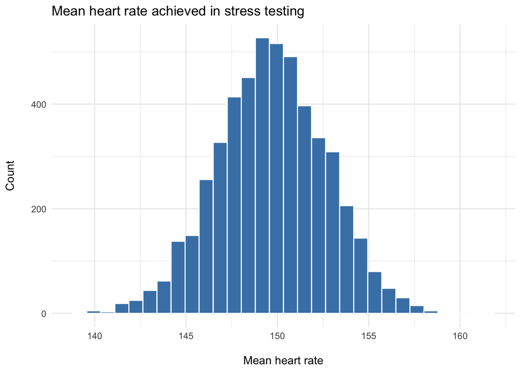

```r
rep_sample_50 %>%
  ggplot(aes(x = mean_thalach)) +
    geom_histogram(colour = "white",
                   fill = "steelblue") +
    labs(
      title = "Mean heart rate achieved in stress testing",
      x = "\nMean heart rate",
      y = "Count\n"
    ) +
  theme_minimal()
```

This is a unimodal distribution.

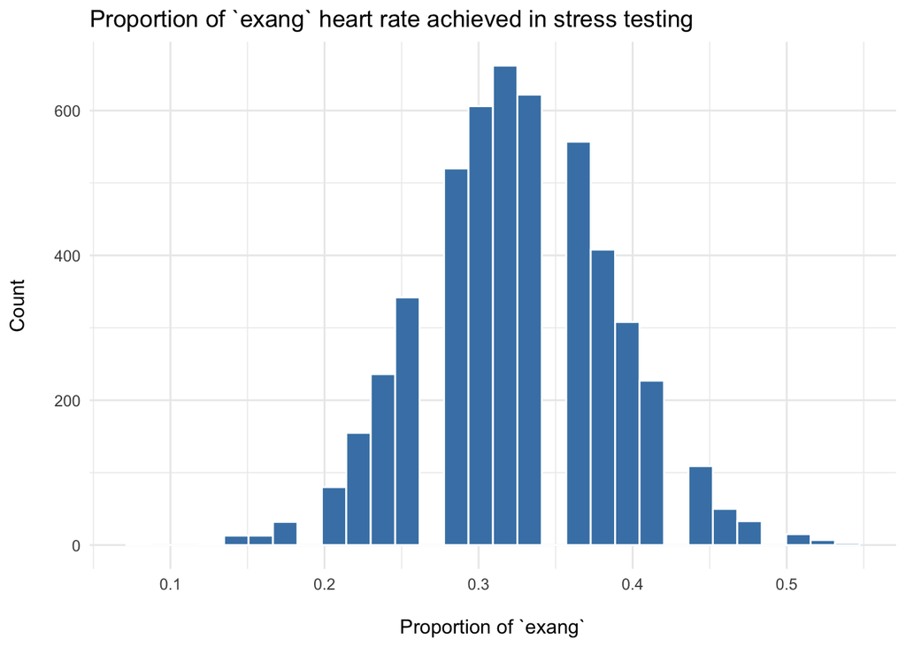

```r
rep_sample_50 %>%
  ggplot(aes(x = prop_exang)) +
    geom_histogram(colour = "white",
                   fill = "steelblue") +
    labs(
      title = "Proportion of `exang` heart rate achieved in stress testing",
      x = "\nProportion of `exang`",
      y = "Count\n"
    ) +
  theme_minimal()
```

This is a unimodal distribution.

9. Obtain standard errors of the sampling distribution of `mean_thalach` and `prop_exang` directly as the standard deviations of the sampling distributions held in `rep_sample_50`

```r
std_errs <- rep_sample_50 %>%
  summarise(
    se_mean_thalach = sd(mean_thalach),
    se_prop_exang = sd(prop_exang)
  )

std_errs
```

| se_mean_thalach | se_prop_exang |
| --- | --- |
| 2.976452 | 0.06160746 |

10. Repeat steps 7. and 9. (omitting step 8.) once more with samples of size 100-patients, and again with samples of size 200-patients. How do the standard errors of `mean_thalach` and `prop_exang` change as sample size increases? Does the *uncertainty* in the calculated statistics *increase* or *decrease* as sample size increases?  
    [**Hint** - it’s OK to copy, paste and alter code to do this!]

```r
sample_100_5000 <- heart %>%
  rep_sample_n(size = 100, reps = 5000)

rep_sample_100 <- sample_100_5000 %>%
  summarise(
    mean_thalach = mean(thalach),
    prop_exang = sum(exang == 1) / n()
   )

rep_sample_100
```

| replicate | mean_thalach | prop_exang |
| --- | --- | --- |
| 1 | 148.94 | 0.37 |
| 2 | 152.79 | 0.27 |
| 3 | 149.04 | 0.33 |
| 4 | 152.32 | 0.32 |
| 5 | 150.34 | 0.32 |
| 6 | 152.06 | 0.30 |
| 7 | 148.70 | 0.37 |
| 8 | 148.84 | 0.35 |
| 9 | 152.17 | 0.33 |
| 10 | 150.47 | 0.35 |

[output cut: 4990 more lines]

```r
std_errs_100 <- rep_sample_100 %>%
  summarise(
    se_mean_thalach = sd(mean_thalach),
    se_prop_exang = sd(prop_exang)
  )

std_errs_100
```

| se_mean_thalach | se_prop_exang |
| --- | --- |
| 1.864747 | 0.03867062 |

```r
sample_200_5000 <- heart %>%
  rep_sample_n(size = 200, reps = 5000)

rep_sample_200 <- sample_200_5000 %>%
  summarise(
    mean_thalach = mean(thalach),
    prop_exang = sum(exang == 1) / n()
   )

rep_sample_200
```

| replicate | mean_thalach | prop_exang |
| --- | --- | --- |
| 1 | 148.320 | 0.350 |
| 2 | 148.210 | 0.355 |
| 3 | 151.220 | 0.315 |
| 4 | 148.365 | 0.340 |
| 5 | 149.730 | 0.335 |
| 6 | 150.680 | 0.330 |
| 7 | 149.955 | 0.325 |
| 8 | 148.020 | 0.310 |
| 9 | 150.305 | 0.330 |
| 10 | 149.275 | 0.330 |

[output cut: 4990 more lines]

```r
std_errs_200 <- rep_sample_200 %>%
  summarise(
    se_mean_thalach = sd(mean_thalach),
    se_prop_exang = sd(prop_exang)
  )

std_errs_200
```

| se_mean_thalach | se_prop_exang |
| --- | --- |
| 0.9419079 | 0.01925576 |

std_errs_100:

| se_mean_thalach | se_prop_exang |
| --- | --- |
| 1.864747 | 0.03867062 |

vs std_errs_200:

| se_mean_thalach | se_prop_exang |
| --- | --- |
| 0.9419079 | 0.01925576 |

.

Standard error roughly halves as the sample size doubles.

The smaller the standard error, the more representative the sample will be of the overall population. More certain = less uncertain.